# VNI Analysis of RDM behavior

Hayley Brooks

Output 1) indivPOCestimates.pdf - plots each sub’s past outcome betas 2) runSizeShiftFigs.pdf- plots change in risk taking following negative shift as a function of shift and run size 3) ocEarnIntxOnly.pdf - risk taking as a fucntion of outcomes x earnings plotting only interaction 4) ocEarnIntx.pdf - risk taking as a function of outcomes x earnings interaction plotting all variables in the model 5) taskEarnings.pdf - earnings for each participant over the task

# Set up the environment/path

```r
rm(list=ls());  # clear environment


library(config)
config <- config::get()

load("/Volumes/shlab/Projects/VNI/data/mriBehaviorClean/group_mriBehavior_clean.Rdata"); # mriBehClean data frame
```

Load packages

```r
library(lme4);
library(lmerTest);
```

Subject information

```r
subIDs = unique(mriBehClean$subjectIndex);
nSub = length(subIDs);
print(nSub)
```

```
## [1] 48
```

FOR THIS ANALYSIS, WE WANT TO KNOW IF RISK TAKING (RESIDUALS) CHANGES AS A FUNCTION OF TEMPORAL CONTEXT AT THREE LEVELS: 1) PAST OUTCOME (IMMEDIATE) 2) SHIFTS (NEIGHBORHOOD) 3) CUMULATIVE EARNINGS (GLOBAL)

INDIVIDUAL-LEVEL ANALYSES DOES RISK-TAKING CHANGE ON THE IMMEDIATE LEVEL OF TEMPORAL CONTEXT? Iindividual-level past outcome glms

```r
subsTriLevMods = list();
subsPocMods = list();
trialLevelResults = as.data.frame(matrix(data = NA, nrow = nSub, ncol=3, dimnames=list(c(NULL), c("subID","beta","pval"))))
pocResults = as.data.frame(matrix(data = NA, nrow = nSub, ncol=3, dimnames=list(c(NULL), c("subID","beta","pval"))))

for (s in 1:nSub) {
  sub = mriBehClean[mriBehClean$subjectIndex==subIDs[s],]; # pull out a single subject

  subsTriLevMods[[s]] = glm(choice~gainSC + altSC + grndEVscaled, data=sub, family="binomial"); # run the trial levelm odel

  sub$pred = predict(subsTriLevMods[[s]],type='link'); # get predicted values

  subsPocMods[[s]] = glm(choice~poc1scaled, data=sub, family="binomial", offset=pred); # past outcome model with predicted values

  tmp =summary(subsPocMods[[s]]); #store coefficients from poc model
  pocResults$subID[s] = subIDs[s]; # fill in sub ID
  pocResults$beta[s] = tmp$coefficients[[2]]; # store beta
  pocResults$pval[s] = tmp$coefficients[[8]]; # store pvalue
};
```

[output not shown]

```r
print(pocResults)
```

```
##    subID         beta         pval
## 1      1 -1.693390832 0.1968871429
## 2      2  0.161193726 0.8471161677
## 3      3  2.577286605 0.0137382061
## 4      4 -0.016855337 0.9823901112
## 5      5  0.838088131 0.6117457376
## 6      6 -0.384923218 0.6492531879
## 7      7 -1.067954869 0.2332696081
## 8      8 -0.300178187 0.6900989334
## 9      9  1.626263189 0.0704141854
## 10    10  0.387301653 0.6083048491
## 11    11  0.003436553 0.9971335710
## 12    12 -0.007504092 0.9948011314
## 13    14  0.366073795 0.7079189389
## 14    15  0.873583933 0.4009790992
```

[output cut: 34 more lines]

```r
sprintf(" %d participants had a negative, significant past outcome beta and %d participants had a positive, significant outcome beta", sum(pocResults$pval<.05 & pocResults$beta <0), sum(pocResults$pval<.05 & pocResults$beta >0))
```

```
## [1] " 3 participants had a negative, significant past outcome beta and 3 participants had a positive, significant outcome beta"
```

Plot the individual past outcome results Blue is trending, green is significant, black is not significant or trending

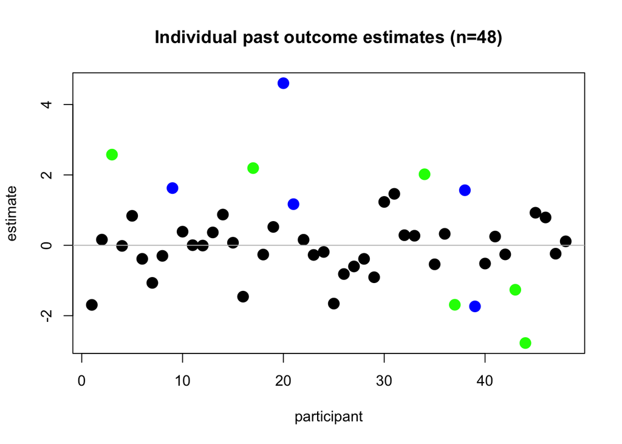

```r
plot(pocResults$beta, ylim=c(min(pocResults$beta),max(pocResults$beta)), pch=16, main=sprintf("Individual past outcome estimates (n=%s)", nSub), xlab="participant", ylab="estimate", col= ifelse(pocResults[,3]<.05, "green", ifelse(pocResults[,3]<.1 & pocResults$pval>.05,"blue", "black")), cex=1.75); # blue is trending, green is significant, black is neither
abline(a=0,b=0, col="grey")
```

GROUP LEVEL ANALYSIS (LME4)

Trial-level variables (model is identical to VIC): Summary: Participants more likely to choose an option as its amount increases (no effect of ground expected value)

```r
model1_trialLevel = glmer(choice~ 0 + gainSC + altSC + grndEVscaled + (0+ gainSC + altSC|subjectIndex), data = mriBehClean, family = "binomial");

summary(model1_trialLevel);
```

```
## Generalized linear mixed model fit by maximum likelihood (Laplace
##   Approximation) [glmerMod]
##  Family: binomial  ( logit )
## Formula: choice ~ 0 + gainSC + altSC + grndEVscaled + (0 + gainSC + altSC |
##     subjectIndex)
##    Data: mriBehClean
##
##      AIC      BIC   logLik deviance df.resid
##   8058.9   8102.4  -4023.4   8046.9    10422
##
## Scaled residuals:
##     Min      1Q  Median      3Q     Max
## -35.149  -0.444  -0.061   0.399 112.462
##
## Random effects:
##  Groups       Name   Variance Std.Dev. Corr
##  subjectIndex gainSC  82.97    9.109
##               altSC  326.92   18.081   -0.97
## Number of obs: 10428, groups:  subjectIndex, 48
##
## Fixed effects:
##              Estimate Std. Error z value Pr(>|z|)
## gainSC         16.118      1.885   8.551   <2e-16 ***
## altSC         -41.078      3.605 -11.394   <2e-16 ***
## grndEVscaled    6.990      5.085   1.374    0.169
## ---
## Signif. codes:  0 '***' 0.001 '**' 0.01 '*' 0.05 '.' 0.1 ' ' 1
##
## Correlation of Fixed Effects:
##             gainSC altSC
## altSC       -0.068
## grndEVscald -0.693 -0.661
```

Pull out “predicted” values from trial-level model and save as variable “pred” in mriBehClean dataframe

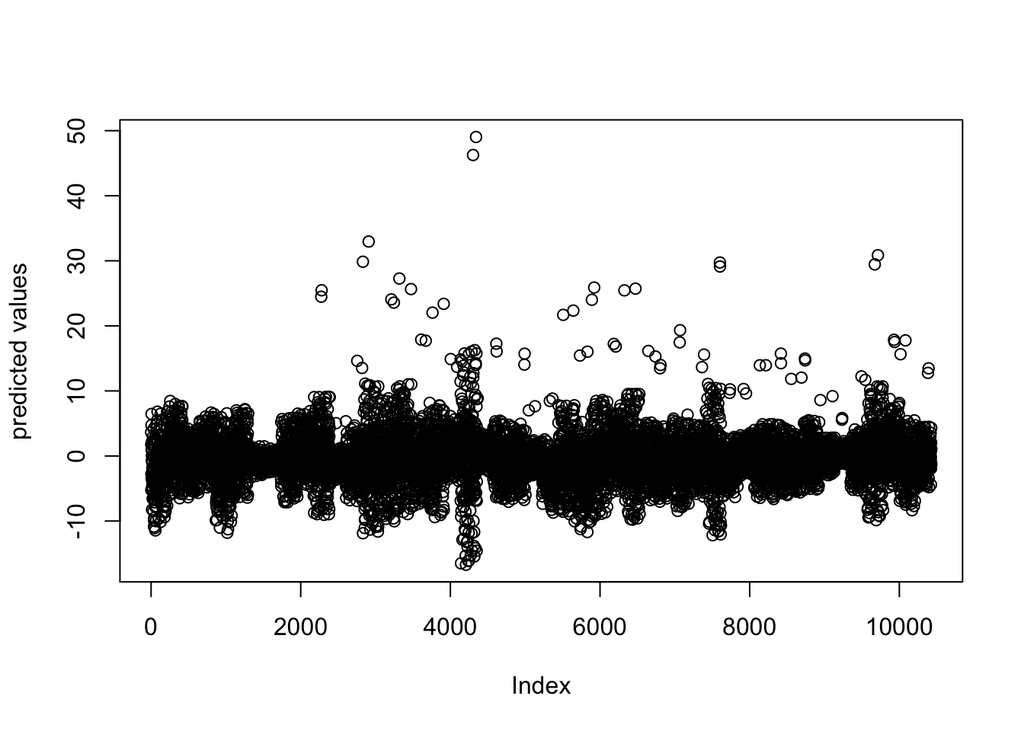

```r
mriBehClean$pred= predict(model1_trialLevel,type="link");
par(mfrow=c(1,1))
plot(mriBehClean$pred, ylab="predicted values");
```

###### Does temporal context influence risk taking?

Each timescale of temporal context in models alone

Timescale 1: Past outcome

```r
model2_potc_amt = glmer(choice ~ 0 + poc1scaled + (1|subjectIndex), data=mriBehClean, family="binomial", offset=pred);
summary(model2_potc_amt);  # ns; AIC = 7592.9
```

```
## Generalized linear mixed model fit by maximum likelihood (Laplace
##   Approximation) [glmerMod]
##  Family: binomial  ( logit )
## Formula: choice ~ 0 + poc1scaled + (1 | subjectIndex)
##    Data: mriBehClean
##  Offset: pred
##
##      AIC      BIC   logLik deviance df.resid
##   7592.9   7607.4  -3794.4   7588.9    10381
##
## Scaled residuals:
##     Min      1Q  Median      3Q     Max
## -35.185  -0.443  -0.062   0.399 112.431
##
## Random effects:
##  Groups       Name        Variance  Std.Dev.
##  subjectIndex (Intercept) 0.0009057 0.0301
## Number of obs: 10383, groups:  subjectIndex, 48
##
## Fixed effects:
##             Estimate Std. Error z value Pr(>|z|)
## poc1scaled 0.0004236  0.0835266   0.005    0.996
```

```r
model2_potc_type = glmer(choice ~ 0 + poc1type + (1|subjectIndex), data=mriBehClean, family="binomial", offset=pred);
summary(model2_potc_type); # ns; AIC =7592.1
```

```
## Generalized linear mixed model fit by maximum likelihood (Laplace
##   Approximation) [glmerMod]
##  Family: binomial  ( logit )
## Formula: choice ~ 0 + poc1type + (1 | subjectIndex)
##    Data: mriBehClean
##  Offset: pred
##
##      AIC      BIC   logLik deviance df.resid
##   7592.1   7606.5  -3794.0   7588.1    10381
##
## Scaled residuals:
##     Min      1Q  Median      3Q     Max
## -35.856  -0.443  -0.062   0.399 110.323
##
## Random effects:
##  Groups       Name        Variance  Std.Dev.
##  subjectIndex (Intercept) 0.0009635 0.03104
## Number of obs: 10383, groups:  subjectIndex, 48
##
## Fixed effects:
##          Estimate Std. Error z value Pr(>|z|)
## poc1type  0.03812    0.04217   0.904    0.366
```

```r
model2_potc_amt_type_intxn = glmer(choice ~ 0 + poc1type*poc1scaled + (1|subjectIndex), data=mriBehClean, family="binomial", offset=pred);
summary(model2_potc_amt_type_intxn); # negative interaction between outcome type and amount; AIC = 7588.0
```

```
## Generalized linear mixed model fit by maximum likelihood (Laplace
##   Approximation) [glmerMod]
##  Family: binomial  ( logit )
## Formula: choice ~ 0 + poc1type * poc1scaled + (1 | subjectIndex)
##    Data: mriBehClean
##  Offset: pred
##
##      AIC      BIC   logLik deviance df.resid
##   7588.0   7616.9  -3790.0   7580.0    10379
##
## Scaled residuals:
##     Min      1Q  Median      3Q     Max
## -32.490  -0.441  -0.062   0.401 114.810
##
## Random effects:
##  Groups       Name        Variance Std.Dev.
##  subjectIndex (Intercept) 0.003258 0.05708
## Number of obs: 10383, groups:  subjectIndex, 48
##
## Fixed effects:
##                     Estimate Std. Error z value Pr(>|z|)
## poc1type             0.12294    0.05584   2.202  0.02768 *
## poc1scaled           0.22060    0.14008   1.575  0.11530
## poc1type:poc1scaled -0.53976    0.19379  -2.785  0.00535 **
## ---
## Signif. codes:  0 '***' 0.001 '**' 0.01 '*' 0.05 '.' 0.1 ' ' 1
##
## Correlation of Fixed Effects:
##             pc1typ pc1scl
## poc1scaled  -0.016
## pc1typ:pc1s -0.453 -0.704
```

Plot the interaction between past outcome amount and type: Outcome type is coded: 0 = safe; 1 = risky gain; -1 = risky loss (always $0)

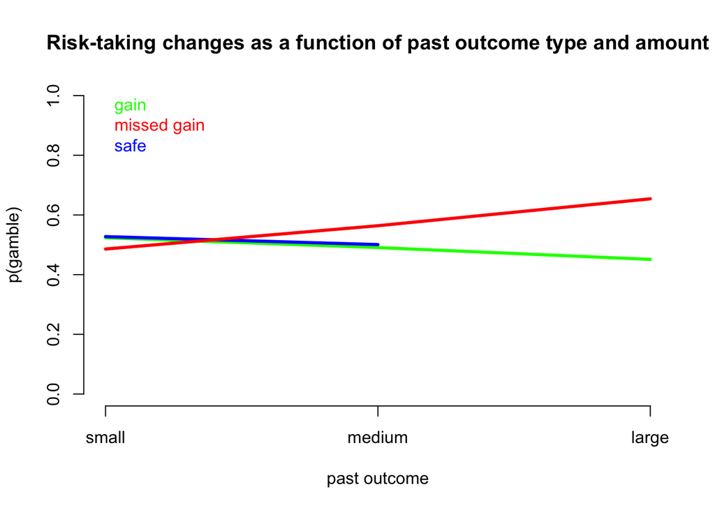

```r
m2coef = fixef(model2_potc_amt_type_intxn); # store all beta estimates

typeCoef = m2coef[1]; # past outcome type coefficient
amtCoef = m2coef[2]; # past outcome amount coefficient
intxnCoef = m2coef[3]; # past outcome type and amount interaction coefficient

## SAFE OUTCOMES
# Largest outcome when a participant rejected gamble = 30.49, scaled = .499918
# smallest outcome when a participant rejected gamble  = .78, scaled = .01278898
PgamPOCsafeSmall = 1/(1+exp(-1*( (typeCoef*0) + (amtCoef*.499918) + (intxnCoef*0*.499918) )));
# probability of gambling following a small, safe past outcome  = 0.5275424, 2.7% increase

PgamPOCsafeLarge = 1/(1+exp(-1*( (typeCoef*0) + (amtCoef*.01278898) + (intxnCoef*0*.01278898) )));
# probability of gambling following a large, safe past outcome  = 0.5007053

## GAINS
# largest outcome when a participant accepted gamble and won = $60.99, scaled = 1
# smallest outcome when a participant accepted gamble and won = $5.31, scaled = 0.08706345
  # technically, the minimum it could be 0 if participants missed an attn check
# medium outcome = $30.5, scaled = .5
# outcome when a participant accepted gamble and lost = $0

PgamPOCwinLarge = 1/(1+exp(-1*( (typeCoef*1) + (amtCoef*1) + (intxnCoef*1*1) )));
# probability of gambling following a large, risky win = 0.4511035, 5% decrease
PgamPOCwinSmall = 1/(1+exp(-1*( (typeCoef*1) + (amtCoef*0.08706345) + (intxnCoef*1*0.08706345) )));
# probability of gambling following a small, risky win = 0.5237715, a 2% increase
PgamPOCwinMedium = 1/(1+exp(-1*( (typeCoef*1) + (amtCoef*.5) + (intxnCoef*1*.5) )));
# probability of gambling following a medium, risky win = 0.4908425, a slight (<1%) decrease


## LOSSES (and MISSED GAINS)
PgamPOClossZero = 1/(1+exp(-1*( (typeCoef*-1) + (amtCoef*0) + (intxnCoef*-1*0) )));
# probability of gambling following a loss = 0.4693025, a 4.5% decrease

PgamPOClossSmallGain = 1/(1+exp(-1*( (typeCoef*-1) + (amtCoef*0.08706345) + (intxnCoef*-1*0.08706345) )));
# probability of gambling following a small missed gain = 0.4858174, a 1.4% decrease

PgamPOClossLargeGain = 1/(1+exp(-1*( (typeCoef*-1) + (amtCoef*1) + (intxnCoef*-1*1) )));
# probability of gambling following a large missed gain = 0.6541677, a 15.4% increase

PgamPOClossMediumGain = 1/(1+exp(-1*( (typeCoef*-1) + (amtCoef*.5) + (intxnCoef*-1*.5) )));
# probability of gambling following a medium missed gain = 0.5639559, a 6.3% increase


plot(c(PgamPOCwinSmall, PgamPOCwinMedium, PgamPOCwinLarge), type="l", col="green", lwd=3, ylim=c(0,1), main="Risk-taking changes as a function of past outcome type and amount", ylab="p(gamble)", xlab="past outcome", axes=F)
legend("topleft", legend=c("gain", "missed gain", "safe"), text.col = c("green", "red", "blue"), bty="n")
axis(2)
axis(1, labels=c("small", "medium", "large"), at=c(1,2,3))
lines(c(PgamPOCsafeSmall,PgamPOCsafeLarge), col="blue", lwd=3)
lines(c(PgamPOClossSmallGain,PgamPOClossMediumGain,PgamPOClossLargeGain), pch=16, col="red", lwd= 3)
```

Timescale 2: Shifts

```r
model3_signed_shifts = glmer(choice~0 + shiftDiffsc + (1|subjectIndex), data=mriBehClean, family="binomial", offset=pred);
```

```
## boundary (singular) fit: see ?isSingular
```

```r
summary(model3_signed_shifts); # signed shift difference, significant
```

```
## Generalized linear mixed model fit by maximum likelihood (Laplace
##   Approximation) [glmerMod]
##  Family: binomial  ( logit )
## Formula: choice ~ 0 + shiftDiffsc + (1 | subjectIndex)
##    Data: mriBehClean
##  Offset: pred
##
##      AIC      BIC   logLik deviance df.resid
##   7660.7   7675.2  -3828.3   7656.7    10426
##
## Scaled residuals:
##     Min      1Q  Median      3Q     Max
## -35.149  -0.445  -0.062   0.400 112.462
##
## Random effects:
##  Groups       Name        Variance Std.Dev.
##  subjectIndex (Intercept) 0        0
## Number of obs: 10428, groups:  subjectIndex, 48
##
## Fixed effects:
##             Estimate Std. Error z value Pr(>|z|)
## shiftDiffsc   1.0576     0.5027   2.104   0.0354 *
## ---
## Signif. codes:  0 '***' 0.001 '**' 0.01 '*' 0.05 '.' 0.1 ' ' 1
## convergence code: 0
## boundary (singular) fit: see ?isSingular
```

```r
model3_abs_shift = glmer(choice ~ 0 + shiftDiffscABs + (1|subjectIndex), data=mriBehClean, family="binomial", offset=pred);
summary(model3_abs_shift); # absolute shift difference, ns
```

```
## Generalized linear mixed model fit by maximum likelihood (Laplace
##   Approximation) [glmerMod]
##  Family: binomial  ( logit )
## Formula: choice ~ 0 + shiftDiffscABs + (1 | subjectIndex)
##    Data: mriBehClean
##  Offset: pred
##
##      AIC      BIC   logLik deviance df.resid
##   7663.1   7677.6  -3829.6   7659.1    10426
##
## Scaled residuals:
##     Min      1Q  Median      3Q     Max
## -35.165  -0.448  -0.062   0.398 112.457
##
## Random effects:
##  Groups       Name        Variance  Std.Dev.
##  subjectIndex (Intercept) 0.0003501 0.01871
## Number of obs: 10428, groups:  subjectIndex, 48
##
## Fixed effects:
##                Estimate Std. Error z value Pr(>|z|)
## shiftDiffscABs   0.7096     0.5026   1.412    0.158
```

```r
model3_pos_neg_shifts = glmer(choice ~ 0 + shiftDiffscPOS + shiftDiffscNEG + (1|subjectIndex), data=mriBehClean, family="binomial", offset=pred);
summary(model3_pos_neg_shifts); # both positive and negative shift difference, only positive significant
```

```
## Generalized linear mixed model fit by maximum likelihood (Laplace
##   Approximation) [glmerMod]
##  Family: binomial  ( logit )
## Formula: choice ~ 0 + shiftDiffscPOS + shiftDiffscNEG + (1 | subjectIndex)
##    Data: mriBehClean
##  Offset: pred
##
##      AIC      BIC   logLik deviance df.resid
##   7660.2   7682.0  -3827.1   7654.2    10425
##
## Scaled residuals:
##     Min      1Q  Median      3Q     Max
## -35.167  -0.447  -0.062   0.399 112.459
##
## Random effects:
##  Groups       Name        Variance Std.Dev.
##  subjectIndex (Intercept) 0.000396 0.0199
## Number of obs: 10428, groups:  subjectIndex, 48
##
## Fixed effects:
##                Estimate Std. Error z value Pr(>|z|)
## shiftDiffscPOS   1.9005     0.7314   2.598  0.00937 **
## shiftDiffscNEG   0.3184     0.6848   0.465  0.64200
## ---
## Signif. codes:  0 '***' 0.001 '**' 0.01 '*' 0.05 '.' 0.1 ' ' 1
##
## Correlation of Fixed Effects:
##             shDPOS
## shftDffsNEG -0.005
```

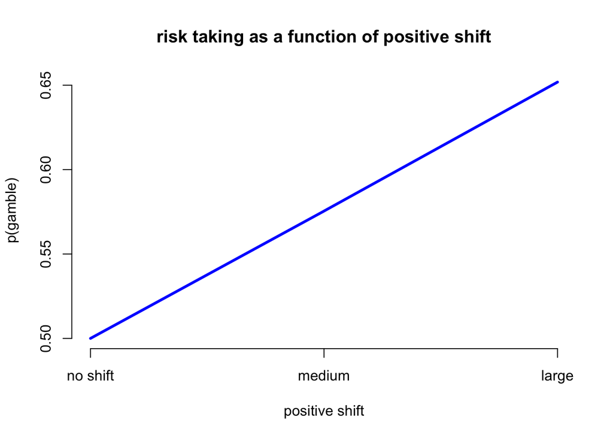

```r
m3_coef_posShift = fixef(model3_pos_neg_shifts)[1];

## Plot the effect of positive shift
# scaled shift amounts = 0 to .33 (or 0 to 20 nonscaled)
PgamPosShiftZero = 1/(1+exp(-1*( (m3_coef_posShift*0) ))); # should be .5
PgamPosShiftLarge = 1/(1+exp(-1*( (m3_coef_posShift*.33) )));
# probability of gambling following large positive shift = 0.6518448, a %15.2 increase
PgamPosShiftMedium = 1/(1+exp(-1*( (m3_coef_posShift*.16) )));
# probability of gambling following medium positive shift = 0.5754388, a %7.5 increase


plot(c(PgamPosShiftZero, PgamPosShiftMedium,PgamPosShiftLarge), type="l", lwd=3, col="blue", axes=F, ylab="p(gamble)", xlab="positive shift", main="risk taking as a function of positive shift")
axis(1, labels=c("no shift", "medium", "large"), at=c(1,2,3))
axis(2)
```

How far back does shift effect go?

```r
# create new positive shift variable (n-1)
newMat = matrix(data=NA,nrow=nrow(mriBehClean), ncol=2);
newMat[,1] <- mriBehClean$shiftDiffscPOS; #take data from columns
newMat[2:nrow(newMat),1] <- newMat[1:(nrow(newMat)-1),1]; # removes first row, shifts everything up
newMat[1,1] <- NaN #put Nan in for first row (first trial for subject 1, bc there is no past trial)
newMat[,2]<-c(0,diff(mriBehClean$subjectIndex)); #put differences between subjectIndex into newvector, 1s show up when subject changes
newMat[newMat[,2]==1,]=NaN; #in newmtx, when diff = 1, replace with NaN, this replaces first trial with nan
mriBehClean$shiftDiffscPOS1 = newMat[,1];# add new vector to mriBehClean

# do the regressions
model3_pos_shift_howfarback = glmer(choice ~ 0 + shiftDiffscPOS + shiftDiffscPOS1 + (1|subjectIndex), data=mriBehClean, family="binomial", offset=pred);
summary(model3_pos_shift_howfarback); #short lasting, only trial directly after a shift
```

```
## Generalized linear mixed model fit by maximum likelihood (Laplace
##   Approximation) [glmerMod]
##  Family: binomial  ( logit )
## Formula: choice ~ 0 + shiftDiffscPOS + shiftDiffscPOS1 + (1 | subjectIndex)
##    Data: mriBehClean
##  Offset: pred
##
##      AIC      BIC   logLik deviance df.resid
##   7587.4   7609.2  -3790.7   7581.4    10380
##
## Scaled residuals:
##     Min      1Q  Median      3Q     Max
## -35.207  -0.448  -0.063   0.398 112.457
##
## Random effects:
##  Groups       Name        Variance Std.Dev.
##  subjectIndex (Intercept) 0.002169 0.04657
## Number of obs: 10383, groups:  subjectIndex, 48
##
## Fixed effects:
##                 Estimate Std. Error z value Pr(>|z|)
## shiftDiffscPOS    1.9151     0.7324   2.615  0.00892 **
## shiftDiffscPOS1   0.6272     0.7546   0.831  0.40586
## ---
## Signif. codes:  0 '***' 0.001 '**' 0.01 '*' 0.05 '.' 0.1 ' ' 1
##
## Correlation of Fixed Effects:
##             shDPOS
## shftDffPOS1 0.006
```

Does positive shift interact with previous run size or past outcome?

```r
# positive shift amount and run size before positive shift
model3_shift_pos_runSize = glmer(choice ~ 0 + shiftDiffscPOS*runSizePOS +(1|subjectIndex), data=mriBehClean, family="binomial", offset=pred);
summary(model3_shift_pos_runSize); # all betas ns
```

```
## Generalized linear mixed model fit by maximum likelihood (Laplace
##   Approximation) [glmerMod]
##  Family: binomial  ( logit )
## Formula: choice ~ 0 + shiftDiffscPOS * runSizePOS + (1 | subjectIndex)
##    Data: mriBehClean
##  Offset: pred
##
##      AIC      BIC   logLik deviance df.resid
##   7661.6   7690.6  -3826.8   7653.6    10424
##
## Scaled residuals:
##     Min      1Q  Median      3Q     Max
## -35.184  -0.449  -0.062   0.398 112.456
##
## Random effects:
##  Groups       Name        Variance  Std.Dev.
##  subjectIndex (Intercept) 0.0007681 0.02772
## Number of obs: 10428, groups:  subjectIndex, 48
##
## Fixed effects:
##                           Estimate Std. Error z value Pr(>|z|)
## shiftDiffscPOS             1.05014    2.54785   0.412    0.680
## runSizePOS                 0.02344    0.02711   0.864    0.387
## shiftDiffscPOS:runSizePOS -0.03565    0.24555  -0.145    0.885
##
## Correlation of Fixed Effects:
##             shDPOS rnSPOS
## runSizePOS  -0.087
## shDPOS:SPOS -0.813 -0.449
```

```r
# both positive and negative shift and run size before positive and negative shift
model3_shift_pos_neg_runSize = glmer(choice ~ 0 + shiftDiffscPOS*runSizePOS + shiftDiffscNEG*runSizeNEG + (1|subjectIndex), data=mriBehClean, family="binomial", offset=pred);
summary(model3_shift_pos_neg_runSize); #all betas ns
```

```
## Generalized linear mixed model fit by maximum likelihood (Laplace
##   Approximation) [glmerMod]
##  Family: binomial  ( logit )
## Formula:
## choice ~ 0 + shiftDiffscPOS * runSizePOS + shiftDiffscNEG * runSizeNEG +
##     (1 | subjectIndex)
##    Data: mriBehClean
##  Offset: pred
##
##      AIC      BIC   logLik deviance df.resid
##   7664.0   7714.8  -3825.0   7650.0    10421
##
## Scaled residuals:
##     Min      1Q  Median      3Q     Max
## -35.186  -0.449  -0.063   0.397 112.457
##
## Random effects:
##  Groups       Name        Variance  Std.Dev.
##  subjectIndex (Intercept) 0.0008075 0.02842
## Number of obs: 10428, groups:  subjectIndex, 48
##
## Fixed effects:
##                           Estimate Std. Error z value Pr(>|z|)
## shiftDiffscPOS             1.05042    2.52116   0.417    0.677
## runSizePOS                 0.02345    0.02711   0.865    0.387
## shiftDiffscNEG             2.95593    2.32178   1.273    0.203
## runSizeNEG                 0.03491    0.02651   1.317    0.188
## shiftDiffscPOS:runSizePOS -0.03569    0.24385  -0.146    0.884
## shiftDiffscNEG:runSizeNEG -0.08937    0.25573  -0.349    0.727
##
## Correlation of Fixed Effects:
##             shDPOS rnSPOS shDNEG rnSNEG sDPOS:
## runSizePOS  -0.086
## shftDffsNEG  0.004 -0.002
## runSizeNEG   0.000  0.002 -0.055
## shDPOS:SPOS -0.810 -0.454 -0.004  0.000
## shDNEG:SNEG -0.004  0.001 -0.829  0.545  0.003
```

```r
# Does positive shift interact with past outcome?
model3_posShift_potc_intxn = glmer(choice ~ 0 + shiftDiffscPOS*poc1scaled + (1|subjectIndex), data=mriBehClean, family="binomial", offset=pred);
summary(model3_posShift_potc_intxn); #all betas ns
```

```
## Generalized linear mixed model fit by maximum likelihood (Laplace
##   Approximation) [glmerMod]
##  Family: binomial  ( logit )
## Formula: choice ~ 0 + shiftDiffscPOS * poc1scaled + (1 | subjectIndex)
##    Data: mriBehClean
##  Offset: pred
##
##      AIC      BIC   logLik deviance df.resid
##   7589.2   7618.2  -3790.6   7581.2    10379
##
## Scaled residuals:
##     Min      1Q  Median      3Q     Max
## -34.795  -0.445  -0.062   0.399 113.189
##
## Random effects:
##  Groups       Name        Variance Std.Dev.
##  subjectIndex (Intercept) 0.001434 0.03787
## Number of obs: 10383, groups:  subjectIndex, 48
##
## Fixed effects:
##                           Estimate Std. Error z value Pr(>|z|)
## shiftDiffscPOS             1.15538    1.09368   1.056    0.291
## poc1scaled                -0.02527    0.08514  -0.297    0.767
## shiftDiffscPOS:poc1scaled  5.30092    5.59480   0.947    0.343
##
## Correlation of Fixed Effects:
##             shDPOS pc1scl
## poc1scaled   0.031
## shftDfPOS:1 -0.741 -0.111
```

Timescale 3: Earnings (and trial) - LEFT OFF HERE 5/17

```r
model4_earnings_trial = glmer(choice~0 + earningsNormalized + trialSC + (1|subjectIndex), data=mriBehClean, family="binomial", offset=pred);
summary(model4_earnings_trial); # both significant, betas similar size but opposite valence, AIC = 7657.1
```

```
## Generalized linear mixed model fit by maximum likelihood (Laplace
##   Approximation) [glmerMod]
##  Family: binomial  ( logit )
## Formula: choice ~ 0 + earningsNormalized + trialSC + (1 | subjectIndex)
##    Data: mriBehClean
##  Offset: pred
##
##      AIC      BIC   logLik deviance df.resid
##   7657.1   7678.9  -3825.6   7651.1    10425
##
## Scaled residuals:
##     Min      1Q  Median      3Q     Max
## -35.826  -0.446  -0.062   0.392 108.219
##
## Random effects:
##  Groups       Name        Variance Std.Dev.
##  subjectIndex (Intercept) 0.003929 0.06268
## Number of obs: 10428, groups:  subjectIndex, 48
##
## Fixed effects:
##                    Estimate Std. Error z value Pr(>|z|)
## earningsNormalized   2.3615     0.8072   2.925  0.00344 **
## trialSC             -2.2802     0.7964  -2.863  0.00420 **
## ---
## Signif. codes:  0 '***' 0.001 '**' 0.01 '*' 0.05 '.' 0.1 ' ' 1
##
## Correlation of Fixed Effects:
##         ernngN
## trialSC -0.998
```

```r
model4_earnings_trial_intxn = glmer(choice~0 + earningsNormalized*trialSC + (1|subjectIndex), data=mriBehClean, family="binomial", offset=pred);
summary(model4_earnings_trial_intxn); # interaction trending, AIC = 7655.5
```

```
## Generalized linear mixed model fit by maximum likelihood (Laplace
##   Approximation) [glmerMod]
##  Family: binomial  ( logit )
## Formula: choice ~ 0 + earningsNormalized * trialSC + (1 | subjectIndex)
##    Data: mriBehClean
##  Offset: pred
##
##      AIC      BIC   logLik deviance df.resid
##   7655.5   7684.5  -3823.8   7647.5    10424
##
## Scaled residuals:
##     Min      1Q  Median      3Q     Max
## -35.548  -0.441  -0.062   0.393 110.485
##
## Random effects:
##  Groups       Name        Variance Std.Dev.
##  subjectIndex (Intercept) 0.002191 0.0468
## Number of obs: 10428, groups:  subjectIndex, 48
##
## Fixed effects:
##                            Estimate Std. Error z value Pr(>|z|)
## earningsNormalized           1.9408     0.8242   2.355  0.01853 *
## trialSC                     -2.2317     0.7870  -2.836  0.00457 **
## earningsNormalized:trialSC   0.4880     0.2561   1.906  0.05668 .
## ---
## Signif. codes:  0 '***' 0.001 '**' 0.01 '*' 0.05 '.' 0.1 ' ' 1
##
## Correlation of Fixed Effects:
##             ernngN trilSC
## trialSC     -0.970
## ernngsNr:SC -0.259  0.025
```

```r
# Earnings interact with past outcome in previous datasets, does that happen here?
model4_earnings_potc_intxn = glmer(choice~0 + earningsNormalized*poc1scaled + trialSC*poc1scaled + (1|subjectIndex), data=mriBehClean, family="binomial", offset=pred);
summary(model4_earnings_potc_intxn); # past outcome, and interaction between outcomes and earnings are significant. Main effects of earnings and trial go away (consistent with previous datasets, eg. VIC). Interaction betwee outcome and trial is trending p =.07
```

```
## Generalized linear mixed model fit by maximum likelihood (Laplace
##   Approximation) [glmerMod]
##  Family: binomial  ( logit )
## Formula: choice ~ 0 + earningsNormalized * poc1scaled + trialSC * poc1scaled +
##     (1 | subjectIndex)
##    Data: mriBehClean
##  Offset: pred
##
##      AIC      BIC   logLik deviance df.resid
##   7560.0   7603.5  -3774.0   7548.0    10377
##
## Scaled residuals:
##     Min      1Q  Median      3Q     Max
## -26.572  -0.435  -0.060   0.396 123.158
##
## Random effects:
##  Groups       Name        Variance Std.Dev.
##  subjectIndex (Intercept) 0.002251 0.04744
## Number of obs: 10383, groups:  subjectIndex, 48
##
## Fixed effects:
##                               Estimate Std. Error z value Pr(>|z|)
## earningsNormalized              0.3019     1.1613   0.260   0.7949
## poc1scaled                     -0.7639     0.1685  -4.533 5.83e-06 ***
## trialSC                        -0.3938     1.1497  -0.343   0.7319
## earningsNormalized:poc1scaled   7.8843     3.3671   2.342   0.0192 *
## poc1scaled:trialSC             -6.1340     3.3301  -1.842   0.0655 .
## ---
## Signif. codes:  0 '***' 0.001 '**' 0.01 '*' 0.05 '.' 0.1 ' ' 1
##
## Correlation of Fixed Effects:
##             ernngN pc1scl trilSC ernN:1
## poc1scaled   0.065
## trialSC     -0.998 -0.065
## ernngsNrm:1 -0.729 -0.090  0.728
## pc1scld:tSC  0.724  0.016 -0.727 -0.995
## convergence code: 0
## Model failed to converge with max|grad| = 0.00450351 (tol = 0.002, component 1)
```

```r
# model fails to converge though
```

Each timescale in a single model:

```r
model5_potc_posshift_earn_trial = glmer(choice ~ 0 + poc1scaled + shiftDiffscPOS + earningsNormalized*poc1scaled + trialSC + (1|subjectIndex), data=mriBehClean, family="binomial", offset=pred)

summary(model5_potc_posshift_earn_trial); # everything significant
```

```
## Generalized linear mixed model fit by maximum likelihood (Laplace
##   Approximation) [glmerMod]
##  Family: binomial  ( logit )
## Formula: choice ~ 0 + poc1scaled + shiftDiffscPOS + earningsNormalized *
##     poc1scaled + trialSC + (1 | subjectIndex)
##    Data: mriBehClean
##  Offset: pred
##
##      AIC      BIC   logLik deviance df.resid
##   7553.0   7596.4  -3770.5   7541.0    10377
##
## Scaled residuals:
##     Min      1Q  Median      3Q     Max
## -25.759  -0.436  -0.061   0.399 126.474
##
## Random effects:
##  Groups       Name        Variance Std.Dev.
##  subjectIndex (Intercept) 0.002773 0.05266
## Number of obs: 10383, groups:  subjectIndex, 48
##
## Fixed effects:
##                               Estimate Std. Error z value Pr(>|z|)
## poc1scaled                     -0.7851     0.1690  -4.644 3.41e-06 ***
## shiftDiffscPOS                  2.4082     0.7481   3.219  0.00129 **
## earningsNormalized              2.0780     0.8107   2.563  0.01037 *
## trialSC                        -2.1952     0.8003  -2.743  0.00609 **
## poc1scaled:earningsNormalized   1.7987     0.3324   5.412 6.25e-08 ***
## ---
## Signif. codes:  0 '***' 0.001 '**' 0.01 '*' 0.05 '.' 0.1 ' ' 1
##
## Correlation of Fixed Effects:
##             pc1scl shDPOS ernngN trilSC
## shftDffsPOS -0.050
## ernngsNrmlz  0.075  0.091
## trialSC     -0.074 -0.106 -0.995
## pc1scld:rnN -0.760  0.083 -0.118  0.070
```